# Practical session: mixed effects models

Radchuk Viktoriia

2022-12-21

# First: your examples

Before we go on with the exercise, let us devote some time to focus on the research questions you want to address in your own projects and what data you have for that. We will Friday devoted to analysing your own data. Please, each of you:

- introduce shortly your data;
- your research question(s);
- have you already tried fitting models?
- have you encountered some difficulties, if so which?

# Read in the data

We continue working with the data looking at the relation between phenology and temperature across species.  
Q: how does temperature affects phenology (e.g. egg laying date) in birds?

```r
dat <- read.csv(file = here::here('data', 'dat_phen_temp_subs.csv'))
head(dat)
```

```
##   ID Year Study_Authors                   Journal Year_pub
## 1  1 1953   Ahola_et_al Journal of Animal Ecology     2009
## 2  1 1954   Ahola_et_al Journal of Animal Ecology     2009
## 3  1 1955   Ahola_et_al Journal of Animal Ecology     2009
## 4  1 1956   Ahola_et_al Journal of Animal Ecology     2009
## 5  1 1957   Ahola_et_al Journal of Animal Ecology     2009
## 6  1 1959   Ahola_et_al Journal of Animal Ecology     2009
##                                                                                                                                    Title
## 1 Great tits lay increasingly smaller clutches than selected for: a study of climate- and density-related changes in reproductive traits
## 2 Great tits lay increasingly smaller clutches than selected for: a study of climate- and density-related changes in reproductive traits
## 3 Great tits lay increasingly smaller clutches than selected for: a study of climate- and density-related changes in reproductive traits
## 4 Great tits lay increasingly smaller clutches than selected for: a study of climate- and density-related changes in reproductive traits
## 5 Great tits lay increasingly smaller clutches than selected for: a study of climate- and density-related changes in reproductive traits
## 6 Great tits lay increasingly smaller clutches than selected for: a study of climate- and density-related changes in reproductive traits
##       Species Taxon Location Longitude Latitude Country      Trait
```

[output cut: 20 more lines]

```r
str(dat)
```

```
## 'data.frame':    750 obs. of  20 variables:
##  $ ID             : int  1 1 1 1 1 1 1 1 1 1 ...
##  $ Year           : int  1953 1954 1955 1956 1957 1959 1960 1961 1962 1963 ...
##  $ Study_Authors  : chr  "Ahola_et_al" "Ahola_et_al" "Ahola_et_al" "Ahola_et_al" ...
##  $ Journal        : chr  "Journal of Animal Ecology" "Journal of Animal Ecology" "Journal of Animal Ecology" "Journal of Animal Ecology" ...
##  $ Year_pub       : int  2009 2009 2009 2009 2009 2009 2009 2009 2009 2009 ...
##  $ Title          : chr  "Great tits lay increasingly smaller clutches than selected for: a study of climate- and density-related changes"| __truncated__ "Great tits lay increasingly smaller clutches than selected for: a study of climate- and density-related changes"| __truncated__ "Great tits la…
##  $ Species        : chr  "Parus major" "Parus major" "Parus major" "Parus major" ...
##  $ Taxon          : chr  "Bird" "Bird" "Bird" "Bird" ...
##  $ Location       : chr  "Askainen" "Askainen" "Askainen" "Askainen" ...
##  $ Longitude      : num  21.8 21.8 21.8 21.8 21.8 ...
##  $ Latitude       : num  60.6 60.6 60.6 60.6 60.6 ...
##  $ Country        : chr  "Finland" "Finland" "Finland" "Finland" ...
##  $ Trait          : chr  "LayingDate" "LayingDate" "LayingDate" "LayingDate" ...
##  $ Trait_Categ_det: chr  "Laying_Date" "Laying_Date" "Laying_Date" "Laying_Date" ...
##  $ Trait_Categ    : chr  "Phenological" "Phenological" "Phenological" "Phenological" ...
##  $ Trait_mean     : num  -1.444 -0.296 1.411 0.587 1.21 ...
##  $ Trait_SE       : num  0.166 0.0842 0.2379 0.2411 0.2762 ...
##  $ Clim           : num  3.426 1.296 -1.191 -0.631 0.757 ...
##  $ det_Clim       : num  1.585 -0.222 -2.323 -1.903 -0.8 ...
##  $ det_Clim2      : num  2.5111 0.0491 5.3941 3.6229 0.6402 ...
```

# Data preparation

Again, convert character variables to factors. Also convert the Study ID to a factor because it technically also is a factor.

```r
dat_fac <- dat %>%
  mutate_if(is.character, as.factor) %>%
  mutate(ID = as.factor(ID))
str(dat_fac)
```

```
## 'data.frame':    750 obs. of  20 variables:
##  $ ID             : Factor w/ 25 levels "1","21","22",..: 1 1 1 1 1 1 1 1 1 1 ...
##  $ Year           : int  1953 1954 1955 1956 1957 1959 1960 1961 1962 1963 ...
##  $ Study_Authors  : Factor w/ 13 levels "Ahola_et_al",..: 1 1 1 1 1 1 1 1 1 1 ...
##  $ Journal        : Factor w/ 7 levels "Behavioural Ecology & Sociobiology",..: 4 4 4 4 4 4 4 4 4 4 ...
##  $ Year_pub       : int  2009 2009 2009 2009 2009 2009 2009 2009 2009 2009 ...
##  $ Title          : Factor w/ 8 levels "Bergmann?s rule and climate change revisited: Disentangling environmental and genetic responses in a wild bird population",..: 3 3 3 3 3 3 3 3 3 3 ...
##  $ Species        : Factor w/ 7 levels "Cyanistes caeruleus",..: 4 4 4 4 4 4 4 4 4 4 ...
##  $ Taxon          : Factor w/ 1 level "Bird": 1 1 1 1 1 1 1 1 1 1 ...
##  $ Location       : Factor w/ 17 levels "Askainen","Boshoek, Antwerp",..: 1 1 1 1 1 1 1 1 1 1 ...
##  $ Longitude      : num  21.8 21.8 21.8 21.8 21.8 ...
##  $ Latitude       : num  60.6 60.6 60.6 60.6 60.6 ...
##  $ Country        : Factor w/ 12 levels "Belgium","Canada",..: 4 4 4 4 4 4 4 4 4 4 ...
##  $ Trait          : Factor w/ 4 levels "ArrivalDate",..: 3 3 3 3 3 3 3 3 3 3 ...
##  $ Trait_Categ_det: Factor w/ 2 levels "Arrival_Date",..: 2 2 2 2 2 2 2 2 2 2 ...
##  $ Trait_Categ    : Factor w/ 1 level "Phenological": 1 1 1 1 1 1 1 1 1 1 ...
##  $ Trait_mean     : num  -1.444 -0.296 1.411 0.587 1.21 ...
##  $ Trait_SE       : num  0.166 0.0842 0.2379 0.2411 0.2762 ...
##  $ Clim           : num  3.426 1.296 -1.191 -0.631 0.757 ...
##  $ det_Clim       : num  1.585 -0.222 -2.323 -1.903 -0.8 ...
##  $ det_Clim2      : num  2.5111 0.0491 5.3941 3.6229 0.6402 ...
```

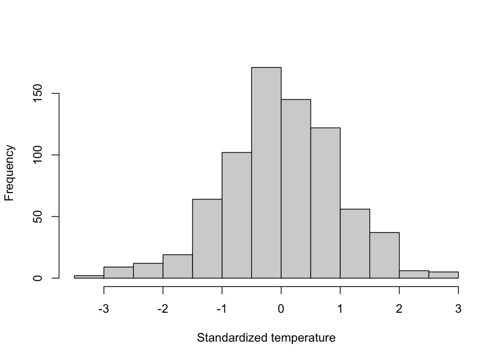

```r
hist(dat_fac$det_Clim, xlab = 'Standardized temperature', main = NULL)
```

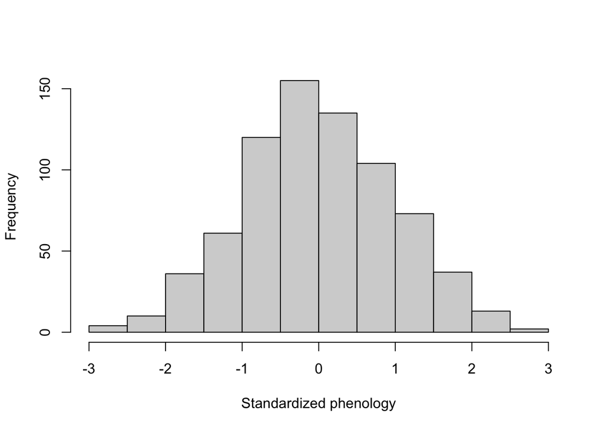

```r
hist(dat_fac$Trait_mean, xlab = 'Standardized phenology', main = NULL)
```

# Relation between temperature and phenology per study

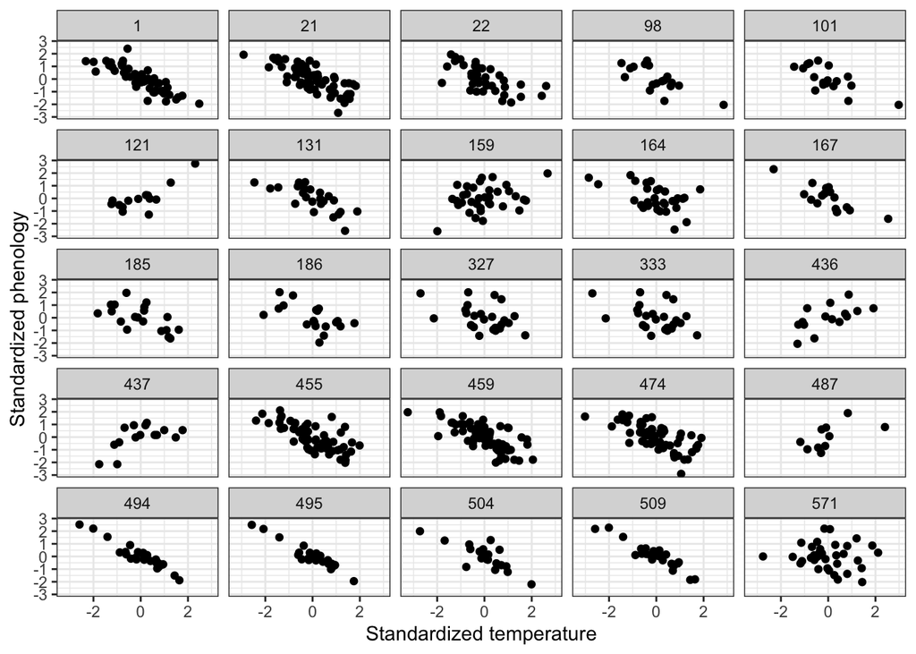

```r
ggplot(dat_fac, aes(x = det_Clim, y = Trait_mean)) +
  geom_point() + theme_bw() +
  facet_wrap(vars(ID)) +
  xlab('Standardized temperature') +
  ylab('Standardized phenology')
```

# Fit mixed effects model with random intercept

We will use the library `spaMM` to fit mixed effects models.  
The syntax is very similar to that of the library `lme4`.  
However, it has some more advanced functionality, which we will need to demonstrate more complex things as we go on.

```r
mod_randInt <- fitme(Trait_mean ~ det_Clim + (1|Species), data = dat_fac, method = 'ML')
```

Note: `Method = 'ML'` is a default setting. This is equivalent to `lme4` syntax `REML = FALSE`. We will learn more about ML and REML in the next lecture!

## Interpreting model output

```r
summary(mod_randInt)
```

```
## formula: Trait_mean ~ det_Clim + (1 | Species)
## Estimation of fixed effects by ML.
## Estimation of lambda and phi by 'outer' ML, maximizing logL.
## family: gaussian( link = identity )
##  ------------ Fixed effects (beta) ------------
##               Estimate Cond. SE    t-value
## (Intercept)  3.322e-16  0.03011  1.103e-14
## det_Clim    -5.448e-01  0.03062 -1.779e+01
##  --------------- Random effects ---------------
## Family: gaussian( link = identity )
##            --- Variance parameters ('lambda'):
## lambda = var(u) for u ~ Gaussian;
##    Species  :  6.803e-07
## # of obs: 750; # of groups: Species, 7
##  -------------- Residual variance  ------------
## phi estimate was 0.679745
##  ------------- Likelihood values  -------------
##                         logLik
## logL       (p_v(h)): -919.4404
```

- **Fixed effects** is interpreted same way as fixed effects from the `lmer()` output. We see the estimates of our parameters, together with thee SErrors and t-values.
- **Random effects** has a similar look as when using the `lmer()` function. We see $\lambda$, which is the variance of the random effect (in this case Species). We also see how many levels for this random effect we had: “number of groups: 7”.
- **Residual variance** gives the residual variance $\phi$. Pay attention: the residual variance is much larger (several orders of magnitude) than that explained by random effect, i.e. compare $\lambda$ and $\phi$.
- **Likelihood** gives the log(Likelihood) of the model, which shows how well the model fits the data. Likelihood is used in calculation of AIC, which is often used for comparing different models.

# Plot predictions

Disclaimer: before doing what we do here, i.e. interpret the model output and plot the predictions, we should actually look at model diagnostics to ensure that this model fits the data reasonably. But we will have a look at how to conduct model diagnostics in the next lecture

Predict to a new dataset, for this prepare the new dataset using the distributions of the variables (and factor levels) from the original dataset.

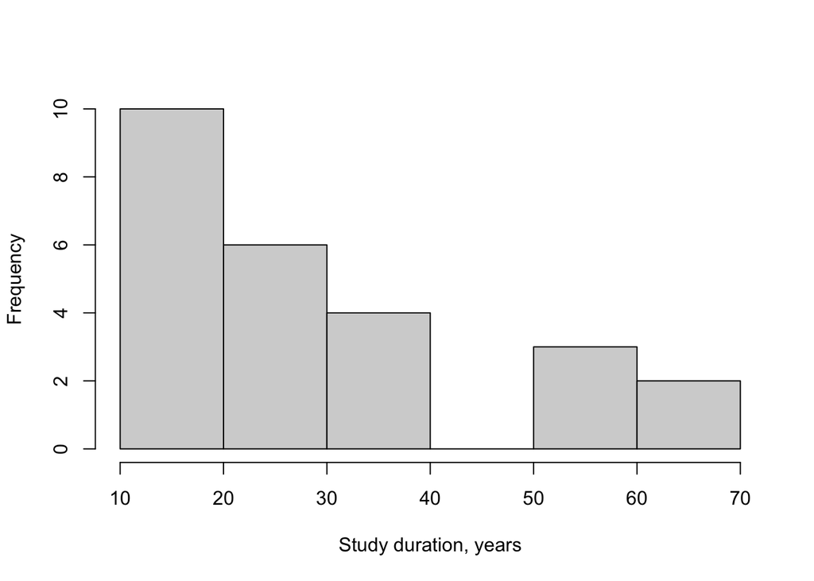

```r
## look at how many years on average are there per study
dur_study <- dat_fac %>%
  dplyr::group_by(., ID) %>%
  dplyr::summarize(Dur = length(Year))

hist(dur_study$Dur, xlab = 'Study duration, years', main = NULL)
```

```r
median(dur_study$Dur)
```

```
## [1] 25
```

```r
newd <- expand.grid('Species' = unique(dat_fac$Species),
                       det_Clim = seq(from = min(dat_fac$det_Clim), to =
                                    max(dat_fac$det_Clim), length.out = 25))

head(newd)
```

```
##               Species  det_Clim
## 1         Parus major -3.246173
## 2 Cyanistes caeruleus -3.246173
## 3          Uria aalge -3.246173
## 4     Hirundo rustica -3.246173
## 5      Sterna hirundo -3.246173
## 6   Sterna paradisaea -3.246173
```

```r
newd$pred_fix <- as.numeric(predict.HLfit(mod_randInt, newdata = newd, re.form = NA))
newd$pred <- as.numeric(predict.HLfit(mod_randInt, newdata = newd)) ## by default re.form = NULL, i.e. including all random effects
```

Remember that to get more information on what each function is doing, you can call the help with “?” as `?predict.HLfit()`.

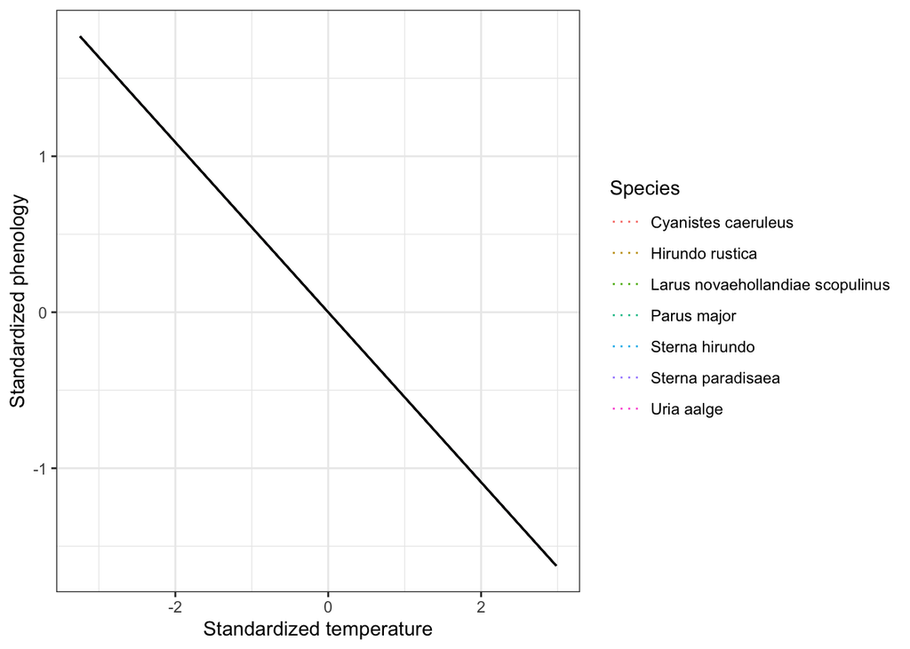

```r
ggplot(data = newd, aes(x = det_Clim, y = pred, group = Species, col = Species)) +
  geom_line(lty = 3) + theme_bw() +
  geom_line(data = newd, aes(x = det_Clim, y = pred_fix), col = 'black') +
  xlab('Standardized temperature') + ylab('Standardized phenology')
```

So, basically, the variance around intercept across species is very small.  
Any idea why this is the case?

In some cases we do not want to show all the random effects but just want to show the fixed effect and the estimated variance around it. Let us see how to do it.  
We use the same new data as was used to produce predictions.

```r
CI_resp <- get_intervals(mod_randInt,newdata=newd, intervals = 'respVar')
CI_fix <- get_intervals(mod_randInt,newdata=newd, intervals = 'fixefVar')
newd <- cbind(newd, CI_resp, CI_fix)
head(newd)
```

```
##               Species  det_Clim pred_fix     pred respVar_0.025 respVar_0.975
## 1         Parus major -3.246173 1.768539 1.768539     0.1398432      3.397235
## 2 Cyanistes caeruleus -3.246173 1.768539 1.768539     0.1398433      3.397235
## 3          Uria aalge -3.246173 1.768539 1.768539     0.1398428      3.397235
## 4     Hirundo rustica -3.246173 1.768539 1.768539     0.1398428      3.397236
## 5      Sterna hirundo -3.246173 1.768539 1.768539     0.1398428      3.397235
## 6   Sterna paradisaea -3.246173 1.768539 1.768539     0.1398427      3.397236
##   fixefVar_0.025 fixefVar_0.975
## 1       1.564982       1.972096
## 2       1.564982       1.972096
## 3       1.564982       1.972096
## 4       1.564982       1.972096
## 5       1.564982       1.972096
## 6       1.564982       1.972096
```

We extract the variance due to the fixed effect (‘fixefVar’) and the one that includes the uncertainty in (i) the fixed effects, (i) in the random effects and the residual variance, i.e. `respVar`.

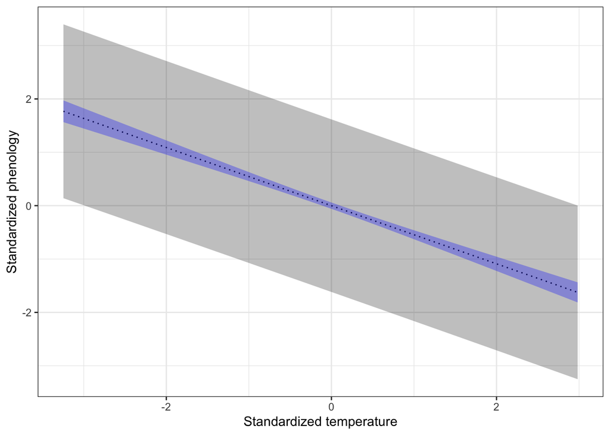

```r
ggplot(data = newd, aes(x = det_Clim, y = pred_fix)) +
  geom_line(lty = 3) + theme_bw() +
  geom_ribbon(data = newd, aes(x = det_Clim, ymin = respVar_0.025, ymax = respVar_0.975), alpha = 0.3) +
  geom_ribbon(data = newd, aes(x = det_Clim, ymin = fixefVar_0.025, ymax = fixefVar_0.975), fill = 'blue',  alpha = 0.3) +
  xlab('Standardized temperature') + ylab('Standardized phenology')
```

The variance due to the fixed effect is shown in the shades of blue, and the total variance (respVar) in the grey shade.

# More non-independence in the data

Not only observations for the same species may be more similar, but the observations coming from the same locations may be more correlated (for example because of a better habitat quality in some locations, which is not accounted for by our focus on temperature).

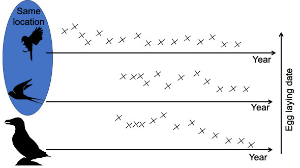

Let us fit a mixed effects model with two independent random intercepts: the one for species and another one for location.

```r
mod_rand2Int <- fitme(Trait_mean ~ det_Clim + (1|Species) + (1|Location), data = dat_fac)
summary(mod_rand2Int)
```

```
## formula: Trait_mean ~ det_Clim + (1 | Species) + (1 | Location)
## Estimation of fixed effects by ML.
## Estimation of lambda and phi by 'outer' ML, maximizing logL.
## family: gaussian( link = identity )
##  ------------ Fixed effects (beta) ------------
##               Estimate Cond. SE    t-value
## (Intercept)  3.301e-16  0.03011  1.096e-14
## det_Clim    -5.448e-01  0.03062 -1.779e+01
##  --------------- Random effects ---------------
## Family: gaussian( link = identity )
##            --- Variance parameters ('lambda'):
## lambda = var(u) for u ~ Gaussian;
##    Species  :  8.952e-07
##    Location  :  1.395e-06
## # of obs: 750; # of groups: Species, 7; Location, 17
##  -------------- Residual variance  ------------
## phi estimate was 0.679745
##  ------------- Likelihood values  -------------
##                         logLik
## logL       (p_v(h)): -919.4413
```

```r
VarCorr(mod_rand2Int)$Variance[VarCorr(mod_rand2Int)$Group == 'Species']
```

```
## [1] 8.951599e-07
```

```r
VarCorr(mod_rand2Int)$Variance[VarCorr(mod_rand2Int)$Group == 'Location']
```

```
## [1] 1.395006e-06
```

We see that the parameter estimates for the fixed effects remain very similar to those estimated when using only Species as a random effect. However, the variance around both random effects (Species and Location) is comparable in its magnitude! Variance for the Species is 8.9515992^{-7} and for the Location it is 1.395006^{-6}

# Consider species explicitly

## Test for interaction between the species and temperature

### Fit a linear model with interaction

```r
mod_SpInteract <- lm(Trait_mean ~ det_Clim + Species + det_Clim:Species, data = dat_fac)
summary(mod_SpInteract)
```

```
##
## Call:
## lm(formula = Trait_mean ~ det_Clim + Species + det_Clim:Species,
##     data = dat_fac)
##
## Residuals:
##      Min       1Q   Median       3Q      Max
## -2.51585 -0.46580  0.00523  0.48144  2.19054
##
## Coefficients:
##                                                    Estimate Std. Error t value
## (Intercept)                                       1.008e-16  4.433e-02   0.000
## det_Clim                                         -7.359e-01  4.508e-02 -16.326
## SpeciesHirundo rustica                           -9.406e-16  1.272e-01   0.000
## SpeciesLarus novaehollandiae scopulinus           4.417e-16  1.319e-01   0.000
## SpeciesParus major                                5.873e-16  6.341e-02   0.000
## SpeciesSterna hirundo                             3.561e-16  1.014e-01   0.000
## SpeciesSterna paradisaea                          7.322e-16  1.949e-01   0.000
## SpeciesUria aalge                                 3.842e-16  1.055e-01   0.000
## det_Clim:SpeciesHirundo rustica                   1.421e-01  1.306e-01   1.089
## det_Clim:SpeciesLarus novaehollandiae scopulinus  6.441e-01  1.339e-01   4.810
## det_Clim:SpeciesParus major                      -2.790e-02  6.430e-02  -0.434
## det_Clim:SpeciesSterna hirundo                    5.239e-01  1.037e-01   5.053
## det_Clim:SpeciesSterna paradisaea                 1.341e+00  2.016e-01   6.655
## det_Clim:SpeciesUria aalge                        1.204e+00  1.081e-01  11.143
##                                                  Pr(>|t|)
## (Intercept)                                         1.000
## det_Clim                                          < 2e-16 ***
## SpeciesHirundo rustica                              1.000
## SpeciesLarus novaehollandiae scopulinus             1.000
## SpeciesParus major                                  1.000
## SpeciesSterna hirundo                               1.000
## SpeciesSterna paradisaea                            1.000
## SpeciesUria aalge                                   1.000
## det_Clim:SpeciesHirundo rustica                     0.277
## det_Clim:SpeciesLarus novaehollandiae scopulinus 1.83e-06 ***
## det_Clim:SpeciesParus major                         0.665
## det_Clim:SpeciesSterna hirundo                   5.48e-07 ***
## det_Clim:SpeciesSterna paradisaea                5.55e-11 ***
## det_Clim:SpeciesUria aalge                        < 2e-16 ***
## ---
## Signif. codes:  0 '***' 0.001 '**' 0.01 '*' 0.05 '.' 0.1 ' ' 1
##
## Residual standard error: 0.7352 on 736 degrees of freedom
## Multiple R-squared:  0.4513, Adjusted R-squared:  0.4416
## F-statistic: 46.57 on 13 and 736 DF,  p-value: < 2.2e-16
```

### Fit a linear model with the additive impact of temperature and species

```r
mod_SpAdd <- lm(Trait_mean ~ det_Clim + Species, data = dat_fac)
summary(mod_SpAdd)
```

```
##
## Call:
## lm(formula = Trait_mean ~ det_Clim + Species, data = dat_fac)
##
## Residuals:
##     Min      1Q  Median      3Q     Max
## -3.6803 -0.5272 -0.0267  0.5302  4.0056
##
## Coefficients:
##                                           Estimate Std. Error t value Pr(>|t|)
## (Intercept)                              1.438e-16  4.998e-02     0.0        1
## det_Clim                                -5.448e-01  3.078e-02   -17.7   <2e-16
## SpeciesHirundo rustica                  -9.959e-16  1.435e-01     0.0        1
## SpeciesLarus novaehollandiae scopulinus  2.198e-16  1.488e-01     0.0        1
## SpeciesParus major                       4.885e-16  7.149e-02     0.0        1
## SpeciesSterna hirundo                    4.028e-16  1.143e-01     0.0        1
## SpeciesSterna paradisaea                -7.834e-16  2.198e-01     0.0        1
## SpeciesUria aalge                        5.416e-16  1.189e-01     0.0        1
##
## (Intercept)
## det_Clim                                ***
## SpeciesHirundo rustica
## SpeciesLarus novaehollandiae scopulinus
## SpeciesParus major
## SpeciesSterna hirundo
## SpeciesSterna paradisaea
## SpeciesUria aalge
## ---
## Signif. codes:  0 '***' 0.001 '**' 0.01 '*' 0.05 '.' 0.1 ' ' 1
##
## Residual standard error: 0.8289 on 742 degrees of freedom
## Multiple R-squared:  0.2968, Adjusted R-squared:  0.2902
## F-statistic: 44.74 on 7 and 742 DF,  p-value: < 2.2e-16
```

## Likelihood-Ratio Test to assess significance of interaction

```r
anova(mod_SpAdd, mod_SpInteract, test = 'Chisq')
```

```
## Analysis of Variance Table
##
## Model 1: Trait_mean ~ det_Clim + Species
## Model 2: Trait_mean ~ det_Clim + Species + det_Clim:Species
##   Res.Df    RSS Df Sum of Sq  Pr(>Chi)
## 1    742 509.81
## 2    736 397.80  6    112.01 < 2.2e-16 ***
## ---
## Signif. codes:  0 '***' 0.001 '**' 0.01 '*' 0.05 '.' 0.1 ' ' 1
```

# Repetition is the mother of all skill

So, we learnt already that the interaction between species and temperature is significant when fitting a linear model.  
Recall from the lecture whether we can grasp this interaction with a mixed-effects model?

# Fit mixed effects model with random slope

```r
mod_randSl <- fitme(Trait_mean ~ det_Clim + (1 + det_Clim|Species), data = dat_fac)
```

## Interpreting the model output

```r
summary(mod_randInt)
```

```
## formula: Trait_mean ~ det_Clim + (1 | Species)
## Estimation of fixed effects by ML.
## Estimation of lambda and phi by 'outer' ML, maximizing logL.
## family: gaussian( link = identity )
##  ------------ Fixed effects (beta) ------------
##               Estimate Cond. SE    t-value
## (Intercept)  3.322e-16  0.03011  1.103e-14
## det_Clim    -5.448e-01  0.03062 -1.779e+01
##  --------------- Random effects ---------------
## Family: gaussian( link = identity )
##            --- Variance parameters ('lambda'):
## lambda = var(u) for u ~ Gaussian;
##    Species  :  6.803e-07
## # of obs: 750; # of groups: Species, 7
##  -------------- Residual variance  ------------
## phi estimate was 0.679745
##  ------------- Likelihood values  -------------
##                         logLik
## logL       (p_v(h)): -919.4404
```

```r
summary(mod_randSl)
```

```
## formula: Trait_mean ~ det_Clim + (1 + det_Clim | Species)
## ML: Estimation of ranCoefs and phi by ML.
##     Estimation of fixed effects by ML.
## Estimation of phi by 'outer' ML, maximizing logL.
## family: gaussian( link = identity )
##  ------------ Fixed effects (beta) ------------
##               Estimate Cond. SE    t-value
## (Intercept)  3.687e-16  0.02672  1.380e-14
## det_Clim    -2.046e-01  0.19244 -1.063e+00
##  --------------- Random effects ---------------
## Family: gaussian( link = identity )
##          --- Random-coefficients Cov matrices:
##    Group        Term      Var.      Corr.
##  Species (Intercept) 5.355e-09
##  Species    det_Clim    0.2467 -2.609e-30
## # of obs: 750; # of groups: Species, 7
##  -------------- Residual variance  ------------
## phi estimate was 0.535465
##  ------------- Likelihood values  -------------
##                         logLik
## logL       (p_v(h)): -841.9528
```

- As with the random intercept model, we have the estimates of **fixed effects**. Notice that the estimate of the fixed slope obtained with the random slope model is much smaller in its magnitude compared to the one estimated with the random intercept model.
- In the output we now have **‘Random coefficients’**, which are estimates of random effects for the intercept (‘Intercept’) and the slope (‘det_Clim’). We see both random variances for each of these terms as well as correlation between them.
- Similar as in the model with the random intercept the residual variance $\phi$ and log(Likelihood) are reported.

Which model do you think fits the data better, the one with the random intercept or with random slope?  
Do we need inclusion of the correlation between the random slope and random intercept?

# Fit yourself the model without correlation between random slope and random intercept!

# Plot predictions with random slope model

We use the data generated for producing the predictions with the random intercept model, as that dataset includes all the predictors we also have in the model with the random slope.

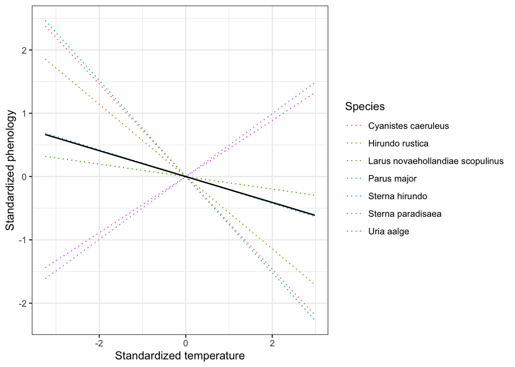

```r
newd$pred_Sl_fix <- as.numeric(predict.HLfit(mod_randSl, newdata = newd, re.form = NA))
newd$pred_Sl <- as.numeric(predict.HLfit(mod_randSl, newdata = newd))

ggplot(data = newd, aes(x = det_Clim, y = pred_Sl, group = Species, col = Species)) +
  geom_line(lty = 3) + theme_bw() +
  geom_line(data = newd, aes(x = det_Clim, y = pred_Sl_fix), col = 'black') +
  xlab('Standardized temperature') + ylab('Standardized phenology')
```

In some cases we do not want to show all the random effects but just want to show the fixed effect and the estimated variance around it. Let us see how to do it.  
This, unfortunately, is still not possible for models with random slopes in spaMM (but is available for random-intercept models).

# Use glmmTMB package to fit mixed-effects models

So, we learn another package that is commonly used to fit mixed-effects models in R. TMB stands for ‘Template Model Builder’.

## A model with random intercept

The syntax is very similar to that used in `lme4`. To fit the model with maximum likelihood we use the same option as in `lme4`, i.e. `REML = FALSE`.

```r
mod_randInt_TMB <- glmmTMB(Trait_mean ~  det_Clim + (1|Species), data = dat_fac, REML = FALSE)
summary(mod_randInt_TMB)
```

```
##  Family: gaussian  ( identity )
## Formula:          Trait_mean ~ det_Clim + (1 | Species)
## Data: dat_fac
##
##      AIC      BIC   logLik deviance df.resid
##   1846.9   1865.4   -919.4   1838.9      746
##
## Random effects:
##
## Conditional model:
##  Groups   Name        Variance  Std.Dev.
##  Species  (Intercept) 2.043e-10 1.429e-05
##  Residual             6.797e-01 8.245e-01
## Number of obs: 750, groups:  Species, 7
##
## Dispersion estimate for gaussian family (sigma^2): 0.68
##
## Conditional model:
##               Estimate Std. Error z value Pr(>|z|)
## (Intercept) -4.490e-08  3.011e-02    0.00        1
## det_Clim    -5.448e-01  3.062e-02  -17.79   <2e-16 ***
## ---
## Signif. codes:  0 '***' 0.001 '**' 0.01 '*' 0.05 '.' 0.1 ' ' 1
```

# Interpreting the results obtained with glmmTMB

The output similar to that obtained with `lme4`:

- First section on the model fit including information on AIC, BIC, log Likelihood, df.
- **Random effects** shows the estimated parameters for random effects. The variance of the random intercept is estimated at 2.0425423^{-10}. Here we also see the estimated residual variance, which is 0.68. It is specified both as “Residual” and as “Dispersion estimate for Gaussian family”.
- **Fixed effects** can be interpreted the same way as the analogous output from `lme4`. Unlike the output of `lme4` glmmTMB still provides the p values (`lme4` stopped doing that because for multiple reasons, spaMM also follows the same philosophy)

Compare to the output obtained with the `spaMM` package

```r
summary(mod_randInt)
```

```
## formula: Trait_mean ~ det_Clim + (1 | Species)
## Estimation of fixed effects by ML.
## Estimation of lambda and phi by 'outer' ML, maximizing logL.
## family: gaussian( link = identity )
##  ------------ Fixed effects (beta) ------------
##               Estimate Cond. SE    t-value
## (Intercept)  3.322e-16  0.03011  1.103e-14
## det_Clim    -5.448e-01  0.03062 -1.779e+01
##  --------------- Random effects ---------------
## Family: gaussian( link = identity )
##            --- Variance parameters ('lambda'):
## lambda = var(u) for u ~ Gaussian;
##    Species  :  6.803e-07
## # of obs: 750; # of groups: Species, 7
##  -------------- Residual variance  ------------
## phi estimate was 0.679745
##  ------------- Likelihood values  -------------
##                         logLik
## logL       (p_v(h)): -919.4404
```

```r
summary(mod_randInt_TMB)
```

```
##  Family: gaussian  ( identity )
## Formula:          Trait_mean ~ det_Clim + (1 | Species)
## Data: dat_fac
##
##      AIC      BIC   logLik deviance df.resid
##   1846.9   1865.4   -919.4   1838.9      746
##
## Random effects:
##
## Conditional model:
##  Groups   Name        Variance  Std.Dev.
##  Species  (Intercept) 2.043e-10 1.429e-05
##  Residual             6.797e-01 8.245e-01
## Number of obs: 750, groups:  Species, 7
##
## Dispersion estimate for gaussian family (sigma^2): 0.68
##
## Conditional model:
##               Estimate Std. Error z value Pr(>|z|)
## (Intercept) -4.490e-08  3.011e-02    0.00        1
## det_Clim    -5.448e-01  3.062e-02  -17.79   <2e-16 ***
## ---
## Signif. codes:  0 '***' 0.001 '**' 0.01 '*' 0.05 '.' 0.1 ' ' 1
```

## A model with random slope

```r
mod_randSl_TMB <- glmmTMB(Trait_mean ~  det_Clim + (1 + det_Clim|Species), data = dat_fac, REML = FALSE)
summary(mod_randSl_TMB)
```

```
##  Family: gaussian  ( identity )
## Formula:          Trait_mean ~ det_Clim + (1 + det_Clim | Species)
## Data: dat_fac
##
##      AIC      BIC   logLik deviance df.resid
##   1695.9   1723.6   -842.0   1683.9      744
##
## Random effects:
##
## Conditional model:
##  Groups   Name        Variance  Std.Dev.  Corr
##  Species  (Intercept) 2.571e-10 1.604e-05
##           det_Clim    2.467e-01 4.967e-01 0.98
##  Residual             5.355e-01 7.318e-01
## Number of obs: 750, groups:  Species, 7
##
## Dispersion estimate for gaussian family (sigma^2): 0.535
##
## Conditional model:
##               Estimate Std. Error z value Pr(>|z|)
## (Intercept)  8.280e-06  3.131e-02   0.000    1.000
## det_Clim    -2.046e-01  1.926e-01  -1.062    0.288
```

# Plot predictions with the random-slope model

We can again use the same (new) dataset whcih we generated for producing the predictions with the random-intercept model.

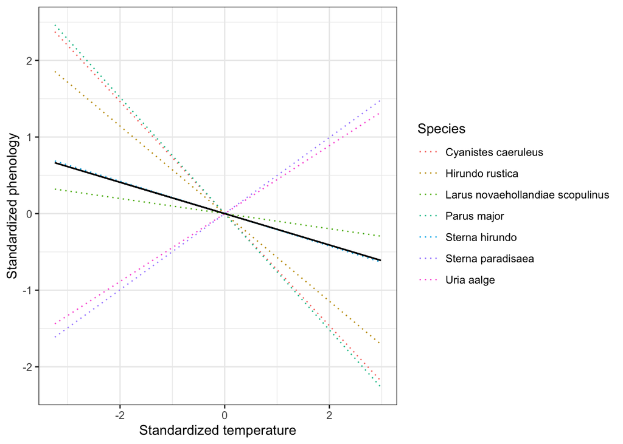

```r
newd$pred_Sl_fixTMB <- predict(mod_randSl_TMB, newdata = newd, re.form = NA, type = 'response')
newd$pred_Sl_TMB <- as.numeric(predict(mod_randSl, newdata = newd, type = 'response'))

ggplot(data = newd, aes(x = det_Clim, y = pred_Sl_TMB, group = Species, col = Species)) +
  geom_line(lty = 3) + theme_bw() +
  geom_line(data = newd, aes(x = det_Clim, y = pred_Sl_fixTMB), col = 'black') +
  xlab('Standardized temperature') + ylab('Standardized phenology')
```

Adding SE to the predictions of the random-slope model. We use the `predict.glmmTMB()` function ot compute SE around the estimates, and use those to compute CI assuming Normal distribution around the mean.

```r
newd$pre_SE_fixTMB <- predict(mod_randSl_TMB, newdata = newd, re.form = NA, se.fit = TRUE, type = 'response')$se.fit
newd$pred_SE_TMB <- predict(mod_randSl_TMB, newdata = newd, re.form = NULL, se.fit = TRUE, type = 'response')$se.fit
newd$pred_upper_fix <- newd$pred_Sl_fixTMB + qnorm(0.975)*newd$pre_SE_fixTMB
newd$pred_lower_fix <- newd$pred_Sl_fixTMB - qnorm(0.975)*newd$pre_SE_fixTMB
head(newd)
```

```
##               Species  det_Clim pred_fix     pred respVar_0.025 respVar_0.975
## 1         Parus major -3.246173 1.768539 1.768539     0.1398432      3.397235
## 2 Cyanistes caeruleus -3.246173 1.768539 1.768539     0.1398433      3.397235
## 3          Uria aalge -3.246173 1.768539 1.768539     0.1398428      3.397235
## 4     Hirundo rustica -3.246173 1.768539 1.768539     0.1398428      3.397236
## 5      Sterna hirundo -3.246173 1.768539 1.768539     0.1398428      3.397235
## 6   Sterna paradisaea -3.246173 1.768539 1.768539     0.1398427      3.397236
##   fixefVar_0.025 fixefVar_0.975 pred_Sl_fix    pred_Sl pred_Sl_fixTMB
## 1       1.564982       1.972096   0.6643204  2.4643062      0.6643287
## 2       1.564982       1.972096   0.6643204  2.3749923      0.6643287
## 3       1.564982       1.972096   0.6643204 -1.4394402      0.6643287
## 4       1.564982       1.972096   0.6643204  1.8557084      0.6643287
## 5       1.564982       1.972096   0.6643204  0.6873636      0.6643287
## 6       1.564982       1.972096   0.6643204 -1.6127100      0.6643287
##   pred_Sl_TMB pre_SE_fixTMB pred_SE_TMB pred_upper_fix pred_lower_fix
## 1   2.4643062     0.6260173   0.1506454         1.8913     -0.5626427
## 2   2.3749923     0.6260173   0.1480679         1.8913     -0.5626427
## 3  -1.4394402     0.6260173   0.3203610         1.8913     -0.5626427
## 4   1.8557084     0.6260173   0.3888218         1.8913     -0.5626427
## 5   0.6873636     0.6260173   0.2989057         1.8913     -0.5626427
## 6  -1.6127100     0.6260173   0.6252352         1.8913     -0.5626427
```

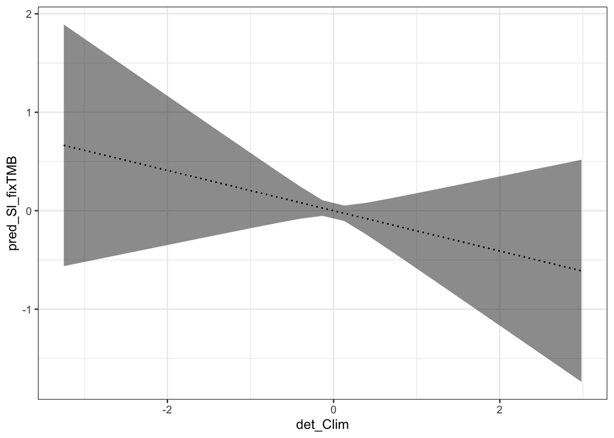

```r
# predictions for the mean response across species
ggplot(data = newd, aes(x = det_Clim, y = pred_Sl_fixTMB, group = Species)) +
  theme_bw() +
  geom_ribbon(data = newd, aes(x = det_Clim, ymin = pred_lower_fix, ymax = pred_upper_fix), alpha = 0.1) +
  geom_line(lty  = 3)
```

And now let us predict with the uncertainty around each level of the random factor.

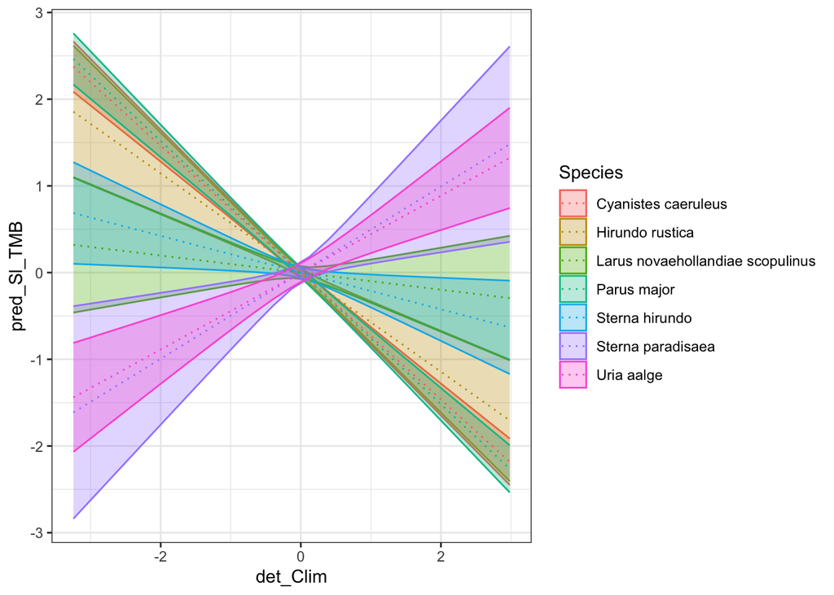

```r
newd$pred_upper <- newd$pred_Sl_TMB + qnorm(0.975)*newd$pred_SE_TMB
newd$pred_lower <- newd$pred_Sl_TMB - qnorm(0.975)*newd$pred_SE_TMB
ggplot(data = newd, aes(x = det_Clim, y = pred_Sl_TMB, group = Species, col = Species)) +
  theme_bw() +
  geom_ribbon(data = newd, aes(x = det_Clim, ymin = pred_lower, ymax = pred_upper, group = Species, fill = Species), alpha = 0.3) +
  geom_line(lty  = 3)
```